# Advanced Classification - Part 4

One should look for what is and not what he thinks should be. (Albert Einstein)

# Warm up

- Before we continue, check out these examples of how machine learning is used: [link](https://medium.com/app-affairs/9-applications-of-machine-learning-from-day-to-day-life-112a47a429d0)
- In the chat, answer the following questions:
  - How do you use machine learning?
  - How do you plan to use methods and tools we’ve learned about so far? Think about specific tasks and goals you would like to achieve.

# Module completion checklist

| Objective | Complete |
| --- | --- |
| Implement base GBM model and assess its performance |  |
| Optimize GBM model using RandomizedCV method |  |
| Use performance metrics to compare all ensemble methods |  |

# Loading packages

- Let’s load the packages we will be using in this module

```python
# Helper packages.
import os
import pickle
import pandas as pd
import matplotlib.pyplot as plt
import numpy as np
import math
from pathlib import Path

# Scikit-learn packages for building models and model evaluation.
from sklearn.model_selection import train_test_split
from sklearn.ensemble import RandomForestClassifier
from sklearn.ensemble import GradientBoostingClassifier
from sklearn.model_selection import RandomizedSearchCV
from sklearn import metrics
```

# Recap: boosting intuition

- In simple linear regression, you can clearly see the residuals, which are the multiple points around the linear model
- Let’s think of these residuals, but apply the concept to decision trees
- When gradient boosting uses decision trees, it follows these three steps:
  - It sees the errors from a decision tree on the dataset
  - **Identifies the pattern of errors** and builds a new decision tree on them
  - It repetitively leverages these patterns in residuals to strengthen the overall model

# Gradient boosted trees

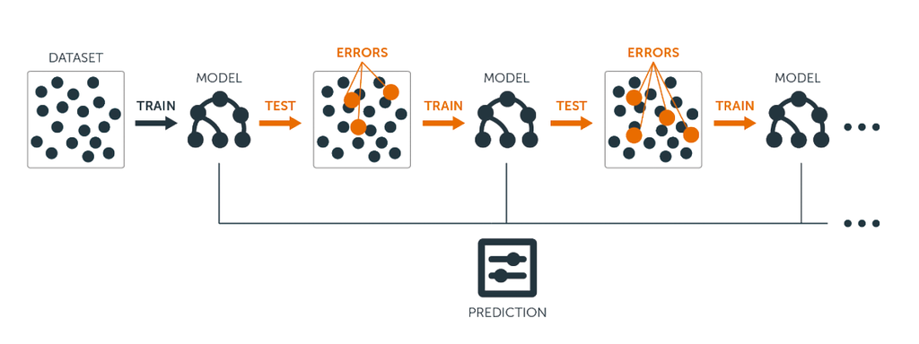

[Image source](https://blog.bigml.com/2017/03/14/introduction-to-boosted-trees/)

# Recap: boosting process

- **Gradient boosting** can be used with classification or regression
- The three simple steps of gradient boosting
  - Fit a decision tree model to the data
  - Fit a decision tree model to the residuals
  - Create a new model
- The generalization of the multiple weak learners occurs by the optimization of a differentiable loss function
- The loss function will change based on the model’s target variable:
  - **Regression**: [gradient descent](https://en.wikipedia.org/wiki/Gradient_descent) used to minimize MSE
  - **Binary classification**: [logistic function](https://en.wikipedia.org/wiki/Logistic_function), yes, the same one we use for estimation of **log loss**!

# Review data cleaning steps

- **Today, we will be loading the cleaned dataset we used earlier**
- To recap, the steps to get to this cleaned dataset were:
  - Remove household ID and individual ID
  - Remove variables with over 50% NAs
  - Transformed target variable to binary

# Directory settings

- In order to maximize the efficiency of your workflow, you should encode your directory structure into `variables`
- We will use the `pathlib` library
- Let the `main_dir` be the variable corresponding to your `course` folder
- Let `data_dir` be the variable corresponding to your `data` folder

```python
# Set 'main_dir' to location of the project folder
home_dir = Path(".").resolve()
main_dir = home_dir.parent.parent
print(main_dir)
```

```python
data_dir = str(main_dir) + "/data"
print(data_dir)
```

# Load the cleaned dataset and model metrics

- Let’s load the dataset: `costa_clean`
- Assign it to `costa_clean` variable

```python
costa_clean = pickle.load(open(data_dir + "/costa_clean.sav","rb"))
metrics_gbm = pickle.load(open(data_dir + "/metrics_forest.sav","rb"))
print(costa_clean.head())
```

```
   rooms  tablet  males_under_12  ...  rural_zone  age  Target
0      3       0               0  ...           0   43    True
1      4       1               0  ...           0   67    True
2      8       0               0  ...           0   92    True
3      5       1               0  ...           0   17    True
4      5       1               0  ...           0   37    True

[5 rows x 81 columns]
```

# Print info for our data

- Let’s view the column names

```python
costa_clean.columns
```

```
Index(['rooms', 'tablet', 'males_under_12', 'males_over_12', 'males_tot',
       'females_under_12', 'females_over_12', 'females_tot', 'ppl_under_12',
       'ppl_over_12', 'ppl_total', 'years_of_schooling', 'wall_block_brick',
       'wall_socket', 'wall_prefab_cement', 'wall_wood', 'floor_mos_cer_terr',
       'floor_cement', 'floor_wood', 'ceiling', 'electric_public',
       'electric_coop', 'toilet_sewer', 'toilet_septic', 'cookenergy_elec',
       'cookenergy_gas', 'trash_truck', 'trash_burn', 'wall_bad', 'wall_reg',
       'wall_good', 'roof_bad', 'roof_reg', 'roof_good', 'floor_bad',
       'floor_reg', 'floor_good', 'disabled_ppl', 'male', 'female', 'under10',
       'free', 'married', 'separated', 'single', 'hh_head', 'hh_spouse',
       'hh_child', 'num_child', 'num_adults', 'num_65plus', 'num_hh_total',
       'dependency_rate', 'male_hh_head_educ', 'female_hh_head_educ',
       'meaneduc', 'educ_none', 'educ_primary_inc', 'educ_primary',
       'educ_secondary_inc', 'educ_secondary', 'educ_undergrad', 'bedrooms',
       'ppl_per_room', 'house_owned_full', 'house_owned_paying',
       'house_rented', 'house_other', 'computer', 'television',
       'num_mobilephones', 'region_central', 'region_Chorotega',
       'region_pacifico', 'region_brunca', 'region_antlantica',
       'region_huetar', 'urban_zone', 'rural_zone', 'age', 'Target'],
      dtype='object')
```

# Split into training and test sets

```python
# Select the predictors and target.
X = costa_clean.drop(['Target'], axis = 1)
y = np.array(costa_clean['Target'])

# Set the seed to 1.
np.random.seed(1)

# Split into training and test sets.
X_train, X_test, y_train, y_test = train_test_split(X, y, test_size = 0.3)
```

# Vanilla GBM model

```python
# Initialize GBM model.
gbm = GradientBoostingClassifier()

# Fit the model to train data.
gbm.fit(X_train, y_train)
```

```
GradientBoostingClassifier()
```

# Convenience function for performance metrics

```python
def get_performance_scores(y_test, y_predict, y_predict_prob, eps=1e-15, beta=0.5):
    from sklearn import metrics
    # Scores keys.
    metric_keys = ["accuracy", "precision", "recall", "f1", "fbeta", "log_loss", "AUC"]
    # Score values.
    metric_values = [None]*len(metric_keys)
    metric_values[0] = metrics.accuracy_score(y_test, y_predict)
    metric_values[1] = metrics.precision_score(y_test, y_predict)
    metric_values[2] = metrics.recall_score(y_test, y_predict)
    metric_values[3] = metrics.f1_score(y_test, y_predict)
    metric_values[4] = metrics.fbeta_score(y_test, y_predict, beta=beta)
    metric_values[5] = metrics.log_loss(y_test, y_predict_prob[:, 1], eps=eps)
    metric_values[6] = metrics.roc_auc_score(y_test, y_predict_prob[:, 1])
    perf_metrics = dict(zip(metric_keys, metric_values))
    return(perf_metrics)
```

# Predict and evaluate vanilla GBM model

```python
# Predict on test data for GBM model.
gbm_y_predict = gbm.predict(X_test)

# Get prediction probabilities for the GBM model.
gbm_y_predict_proba = gbm.predict_proba(X_test)

# Get the GBM performance scores.
gbm_scores = get_performance_scores(y_test, gbm_y_predict, gbm_y_predict_proba)
```

# Precision vs recall curve: the tradeoff

- Plot precision vs recall curve for GBM classifier

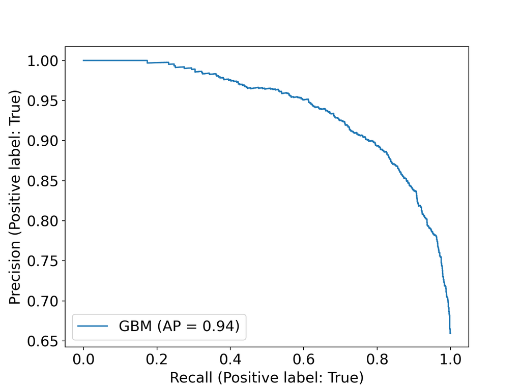

```python
ax = plt.gca()
gbm_prec_recall = metrics.plot_precision_recall_curve(gbm,
                                    X_test,
                                    y_test,
                                    ax = ax,
                                    name = "GBM")

plt.show()
```

# ROC curve: the tradeoff

```python
ax = plt.gca()
gbm_roc = metrics.plot_roc_curve(gbm,
                                 X_test,
                                 y_test,
                                 ax = ax,
                                 name = "GBM")


plt.show()
```

- Looks like the ROC curve shows similar results
- Let’s see if parameter tuning of the GBM can make it better

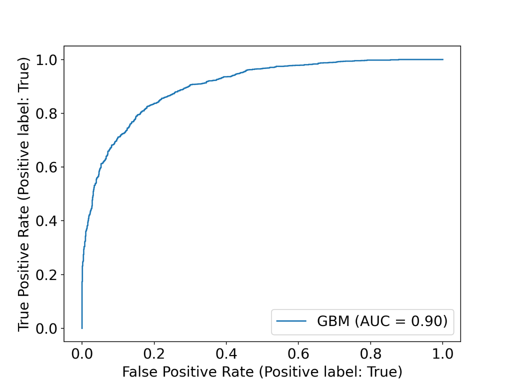

# Append to other model performance scores

```python
metrics_gbm.update({"GBM": gbm_scores})
print(metrics_gbm)
```

```
{'RF': {'accuracy': 0.9483960948396095, 'precision': 0.9447424892703863, 'recall': 0.9750830564784053, 'f1': 0.9596730245231607, 'fbeta': 0.9506586050529044, 'log_loss': 0.21947942349408847, 'AUC': 0.986855647527701}, 'Optimized RF': {'accuracy': 0.9483960948396095, 'precision': 0.9400212314225053, 'recall': 0.9806201550387597, 'f1': 0.9598915989159891, 'fbeta': 0.9478698351530723, 'log_loss': 0.21667604220201855, 'AUC': 0.9876901226920936}, 'GBM': {'accuracy': 0.8291492329149233, 'precision': 0.8374358974358974, 'recall': 0.9042081949058693, 'f1': 0.869542066027689, 'fbeta': 0.8499895898396836, 'log_loss': 0.39102395649143923, 'AUC': 0.902052011186816}}
```

# Module completion checklist

| Objective | Complete |
| --- | --- |
| Implement base GBM model and assess its performance | **✔** |
| Optimize GBM model using RandomizedCV method |  |
| Use performance metrics to compare all ensemble methods |  |

# Ways to optimize gradient boosting

- As with our RF model, we can use various parameter tuning techniques
- In this instance we will repeat the process of randomized grid search
- Since GBM parameters are almost identical to those of RF models, we will keep all of them the same except for one:
  - We will not use `ccp_alpha` - it will be set to default `0.0` value
  - We will instead tune `learning_rate` - the rate with which the error is corrected

# Randomized CV for GBM optimization: parameters

```python
gbm = GradientBoostingClassifier()
# Number of trees in random forest.
n_estimators = [int(x) for x in np.linspace(start = 200, stop = 2000, num = 20)]
# Number of features to consider at every split.
max_features = ['auto', 'sqrt']
# Maximum number of levels in tree.
max_depth = [int(x) for x in np.linspace(10, 110, num = 11)]
max_depth.append(None)
# Minimum number of samples required to split a node.
min_samples_split = [2, 5, 10]
# Minimum number of samples required at each leaf node.
min_samples_leaf = [1, 2, 4]
# Define learning rate parameters.
learning_rate = [0.001, 0.01, 0.1, 0.2, 0.3]
```

# Randomized CV for GBM optimization: create grid

```python
# Create the random grid.
random_grid = {'n_estimators': n_estimators,
               'max_features': max_features,
               'max_depth': max_depth,
               'min_samples_split': min_samples_split,
               'min_samples_leaf': min_samples_leaf,
               'learning_rate': learning_rate}
```

# Randomized CV for GBM optimization: fit

- Initialize randomized search for GBM
- Fit the model to the train data

```python
# Initialize the randomized search model just as you would any other scikit model.
gbm_random = RandomizedSearchCV(estimator = gbm,
                                param_distributions = random_grid,
                                n_iter = 100,
                                cv = 3,
                                verbose = 0,
                                random_state = 1,
                                n_jobs = -1)

# Fit the random search model.
gbm_random.fit(X_train, y_train)
```

*This function may run 30+ minutes! If you would like to skip this step, simply load the pre-saved model as shown below.*

```python
gbm_random = pickle.load(open(data_dir + "/gbm_random.sav","rb"))
```

```python
gbm_random.best_params_
```

```
{'n_estimators': 578, 'min_samples_split': 5, 'min_samples_leaf': 4, 'max_features': 'auto', 'max_depth': 30, 'learning_rate': 0.1}
```

# Implement optimized GBM model

- Now, we will run the optimized model on our `X_train`
- We will again pass the parameters to GMB classifier directly from the result of our randomized search by using the `**parameters` notation

```python
# Pass parameters from randomized search to GBM classifier.
optimized_gbm = GradientBoostingClassifier(**gbm_random.best_params_)

# Fit model to train data.
optimized_gbm.fit(X_train, y_train)
```

```
GradientBoostingClassifier(max_depth=30, max_features='auto',
                           min_samples_leaf=4, min_samples_split=5,
                           n_estimators=578)
```

# Knowledge check 1


# Exercise 1

# Module completion checklist

| Objective | Complete |
| --- | --- |
| Implement base GBM model and assess its performance | **✔** |
| Optimize GBM model using RandomizedCV method | **✔** |
| Use performance metrics to compare all ensemble methods |  |

# Predict and evaluate optimized GBM model

- Predict on test using the optimized GBM model
- Compute performance metrics

```python
# Get class predictions.
optimized_gbm_y_predict = optimized_gbm.predict(X_test)

# Get prediction probabilities.
optimized_gbm_y_predict_proba = optimized_gbm.predict_proba(X_test)

# Compute performance metrics.
optimized_gbm_scores = get_performance_scores(y_test,
                                              optimized_gbm_y_predict,
                                              optimized_gbm_y_predict_proba)
```

# Precision vs recall curve: the tradeoff

- Plot precision vs recall fore optimized GBM model
- Add all previous model curves to compare

```python
ax = plt.gca()
opt_gbm_prec_recall = metrics.plot_precision_recall_curve(optimized_gbm,
                                    X_test,
                                    y_test,
                                    ax = ax,
                                    name = "Optimized GBM")

gbm_prec_recall.plot(ax = ax, name = "GBM")
plt.show()
```

- We can clearly see how much better the optimized GBM performed compared to the vanilla GBM

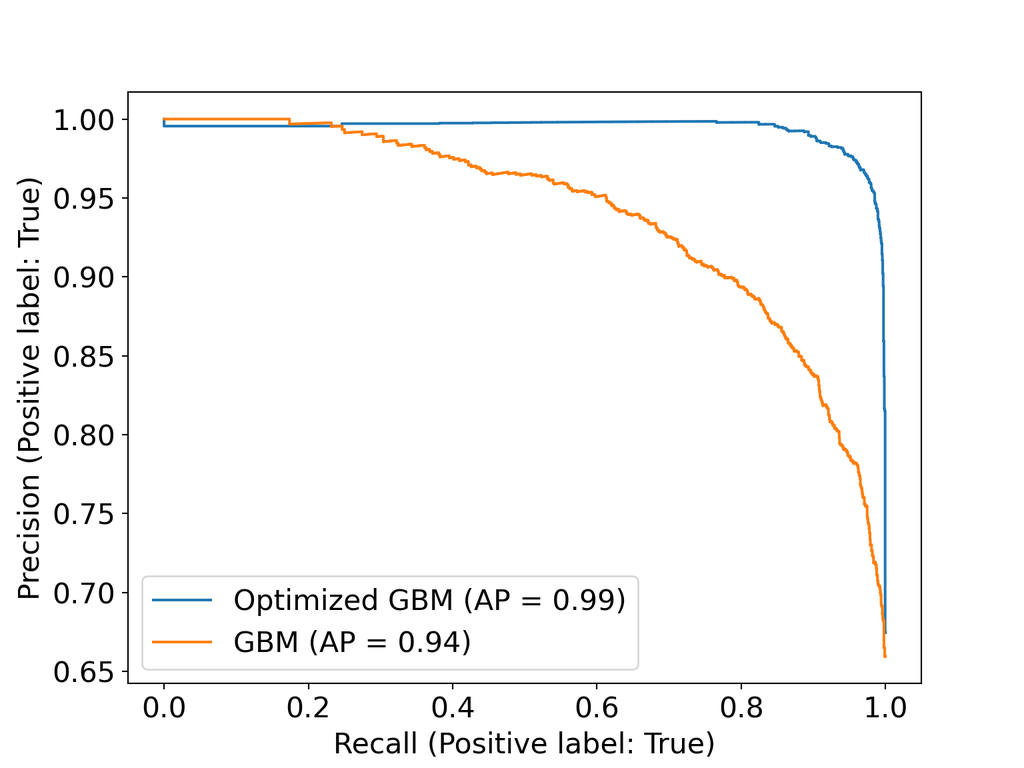

# ROC curve: the tradeoff

```python
ax = plt.gca()
opt_gbm_roc = metrics.plot_roc_curve(optimized_gbm,
                                     X_test,
                                     y_test,
                                     ax = ax,
                                     name = "Optimized GBM")


gbm_roc.plot(ax = ax, name = "GBM")
plt.show()
```

- The same holds for the ROC curve and the AUC!

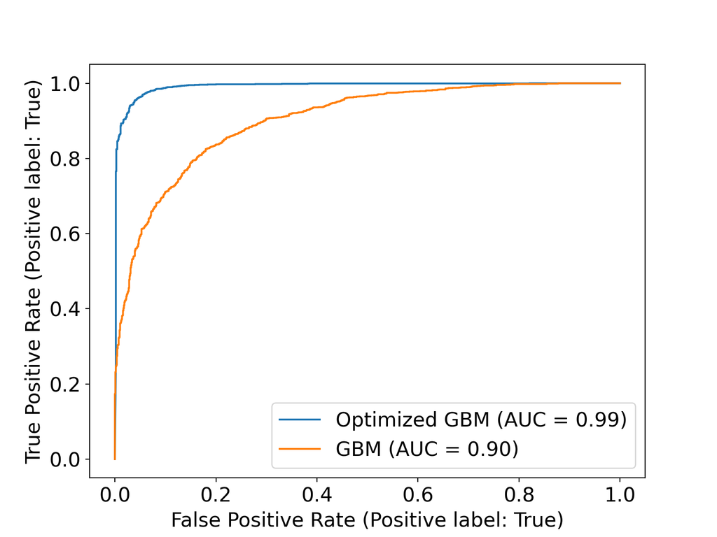

# Append to other model performance scores

- Let’s append optimized GBM scores to the dictionary and then take a look at them all next to each other

```python
metrics_gbm.update({"Optimized GBM": optimized_gbm_scores})
print(metrics_gbm)
```

```
{'RF': {'accuracy': 0.9483960948396095, 'precision': 0.9447424892703863, 'recall': 0.9750830564784053, 'f1': 0.9596730245231607, 'fbeta': 0.9506586050529044, 'log_loss': 0.21947942349408847, 'AUC': 0.986855647527701}, 'Optimized RF': {'accuracy': 0.9483960948396095, 'precision': 0.9400212314225053, 'recall': 0.9806201550387597, 'f1': 0.9598915989159891, 'fbeta': 0.9478698351530723, 'log_loss': 0.21667604220201855, 'AUC': 0.9876901226920936}, 'GBM': {'accuracy': 0.8291492329149233, 'precision': 0.8374358974358974, 'recall': 0.9042081949058693, 'f1': 0.869542066027689, 'fbeta': 0.8499895898396836, 'log_loss': 0.39102395649143923, 'AUC': 0.902052011186816}, 'Optimized GBM': {'accuracy': 0.9592050209205021, 'precision': 0.9678670360110804, 'recall': 0.9673311184939092, 'f1': 0.9675990030462477, 'fbeta': 0.9677598050077555, 'log_loss': 0.5621060823499561, 'AUC': 0.9918591095177615}}
```

# Convert metrics dictionary to dataframe

- Let’s convert our dictionary to a dataframe

```python
# Convert all metrics for each model to a dataframe.
metrics_gbm_df = pd.DataFrame(metrics_gbm)
metrics_gbm_df["metric"] = metrics_gbm_df.index
metrics_gbm_df = metrics_gbm_df.reset_index(drop = True)
print(metrics_gbm_df.head())
```

```
         RF  Optimized RF       GBM  Optimized GBM     metric
0  0.948396      0.948396  0.829149       0.959205   accuracy
1  0.944742      0.940021  0.837436       0.967867  precision
2  0.975083      0.980620  0.904208       0.967331     recall
3  0.959673      0.959892  0.869542       0.967599         f1
4  0.950659      0.947870  0.849990       0.967760      fbeta
```

# Convert wide to long format

- To help with plotting, let’s switch our wide dataframe to long format using `melt` function

```python
metrics_gbm_long = pd.melt(metrics_gbm_df,
                          id_vars = "metric",
                          var_name = "model",
                          value_vars = list(metrics_gbm.keys()))
print(metrics_gbm_long.head())
```

```
      metric model     value
0   accuracy    RF  0.948396
1  precision    RF  0.944742
2     recall    RF  0.975083
3         f1    RF  0.959673
4      fbeta    RF  0.950659
```

- Take a look at the documentation [here](https://pandas.pydata.org/docs/reference/api/pandas.melt.html) for more details on this function

# Plot all models by metric

- Since we converted our metrics dataframe to `long` format, it’s now easy to plot each model grouped by metric in a grid
- Each plot within a grid will be a bar chart with as many bars as there are models

```python
# Create a 2X3 grid.
fig, axes = plt.subplots(2, 3, figsize = (12, 6))
# For each group in a grouped by metric dataframe, assign a metric to an axis object.
for (metric, group), ax in zip(metrics_gbm_long.groupby("metric"), axes.flatten()):
    # Plot each metric as a bar plot.
    group.plot(x = 'model',                                #<- model on x-axis
               y = 'value',                                #<- metric value on y-axis
               kind = 'bar',                               #<- bar plot
               color = ["red", "green", "blue", "orange"], #<- color for each model
               ax = ax,                                    #<- axis object
               title = metric,                             #<- plot title
               legend = None,                              #<- remove auto-legend
               sharex = True)                              #<- use the same x-axis
    ax.xaxis.set_tick_params(rotation = 45, labelsize=10)                #<- rotate labels for prettiness
plt.tight_layout(0.5)                                      #<- make sure no space is unused
plt.show()
```

# Plot all models by metric

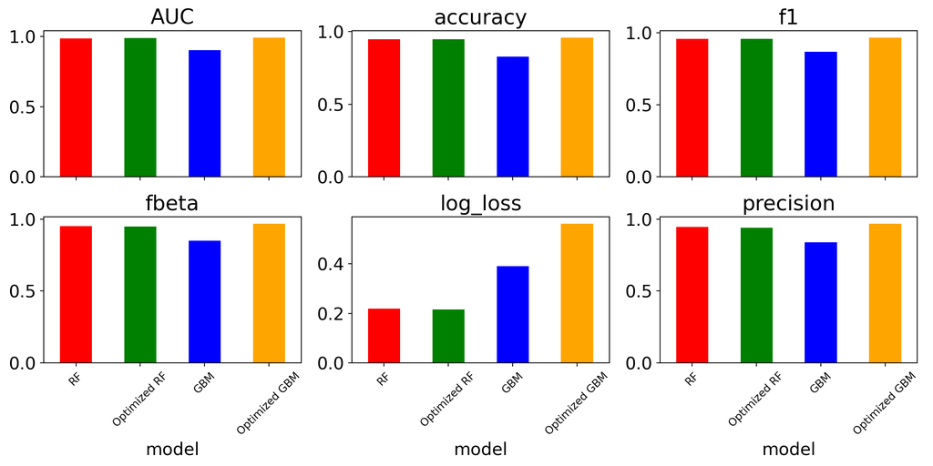

# Wrap comparison plot into a function

```python
def compare_metrics(metrics_dict, color_list = None):
    metrics_df = pd.DataFrame(metrics_dict)
    metrics_df["metric"] = metrics_df.index
    metrics_df = metrics_df.reset_index(drop = True)
    metrics_long = pd.melt(metrics_df, id_vars = "metric", var_name = "model",
                           value_vars = list(metrics_dict.keys()))
    if color_list is None:
        cmap = plt.rcParams['axes.prop_cycle'].by_key()['color']
        colors = cmap[:len(metrics_dict.keys())]
    else:
        colors = color_list
    fig, axes = plt.subplots(2, 3, figsize = (12, 6))
    for (metric, group), ax in zip(metrics_long.groupby("metric"), axes.flatten()):
        group.plot(x = 'model', y = 'value', kind = 'bar', color = colors, ax = ax,
                   title = metric,legend = None,sharex = True)
        ax.xaxis.set_tick_params(rotation = 45, labelsize=10)
    plt.tight_layout(0.5)
    return((fig, axes))
```

# Test function

```python
fig, axes = compare_metrics(metrics_gbm)
```

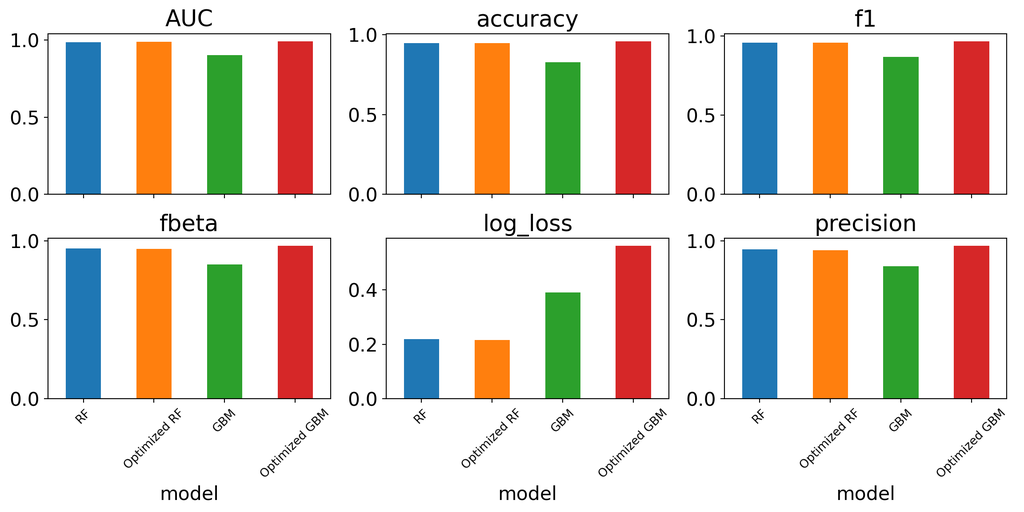

```python
plt.show()
```

# Discuss model champion

# Exercise 2

# Module completion checklist

| Objective | Complete |
| --- | --- |
| Implement base GBM model and assess its performance | **✔** |
| Optimize GBM model using RandomizedCV method | **✔** |
| Use performance metrics to compare all ensemble methods | **✔** |

# Next Steps

- So far, we have studied ensemble methods like Random Forest and Gradient Boosting Models for classification
- Every dataset is different and no one classification algorithm is a best fit for all types of datasets
- What if you have high dimensional data at work and you have to classify a target variable?
- What if your dataset contains more categorical variables?
- In the next module, we will learn about Support vector machines which were developed to handle such issues in our dataset

# Congratulations on completing this module!